# Ptychodera Cisreg Development: Transcription Factor Analysis (Amphioxus)

Alberto Perez-Posada

4/26/2023

## About

In this markdown we will analyse the expression of transcription factor genes during the development of Amphioxus. For this we will use both the counts data we retrieved from our RNA-seq reanalysis and the transcription factor annotation we did in a previous separate markdown.

## Load libraries

```r
library(ComplexHeatmap)
library(circlize)
library(topGO)
library(tidyverse)
```

## Load functions

```r
source("code/r_code/r_functions/sourcefolder.r")

sourceFolder(
  "code/r_code/r_functions",
  recursive = TRUE
  )
```

```
## 42 files sourced from folder "code/r_code/r_functions"
```

```r
sourceFolder(
  "code/r_code/r_general",
  recursive = TRUE
  )
```

```
## 4 files sourced from folder "code/r_code/r_general"
```

## Data Load

We will load the normalised counts for DESeq2:

```r
# Counts and stage-specific clusters
load("outputs/rda/blan_reanalysis.rda")

# TF annotation
load("outputs/rda/TF_annotation.rda")
```

## Amohioxus TF Gene Expresion Overview

We will slice the dataset of counts to retrieve just the genes that are annotated as TFs.

```r
blan_tfs$id <-
  translate_ids(
    x = gsub("_.*","",blan_tfs$id),
    dict = bl_brala
  )


blan_tfs_vsd <-
  RNA_blan[
    rownames(RNA_blan) %in% blan_tfs$id,
    ]

colnames(blan_tfs_vsd) <- colnames(blan_tfs_vsd)

blan_tfs_vsd <- as.data.frame(blan_tfs_vsd)
```

From here we do two things:

- We correlate the expression profile of all TF genes to detect patterns of coexpression.
- We create a heatmap to visualise these patterns of coexpression.

```r
clu_method <- "ward.D2"

# The Heatmaps themselves
blan_tfs_sp_hm <- Heatmap(
  name="Spearman",
  cor(
    scale(t(blan_tfs_vsd[,1:12])),
    method="sp" # Spearman correlation
  ),
  clustering_method_columns = clu_method,
  clustering_method_rows = clu_method,
  col=tfs_sp_hm_col,
  show_row_names = FALSE,
  show_column_names = FALSE
  )

blan_tfs_exp_hm <- Heatmap(
  name="norm\nexpr",
  t(scale(t(blan_tfs_vsd[,1:12])))+2, # +2 for visualisation purposes
  col=tfs_expr_hm_col,
  show_row_names = FALSE,
  show_column_names = FALSE,
  cluster_rows=T,
  clustering_method_rows = "ward.D2",
  cluster_columns=F
  )
```

And here to visualise them both:

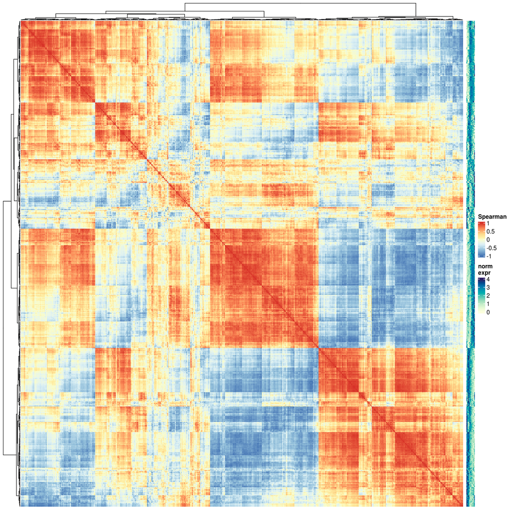

```r
draw(blan_tfs_sp_hm + blan_tfs_exp_hm)
```

## Transcription Factor Class Abundance throughout development

To help us discern some patterns in the expression of these TFs, we can rely on TF Class annotation to see if there are major differences in the control of gene expression at the TF class level.

For this we will prepare the counts dataset and keep the TFs of the top classes.

```r
blan_rna_counts_rowmeansbyrepl <-
    as.data.frame(
    base::sapply(
      unique(sub("_.$", "", colnames(blan_counts))),
      rowMeans_by_repl,
      blan_counts
      )
  )

rownames(blan_rna_counts_rowmeansbyrepl) <- rownames(blan_counts)

blan_tfs_counts_topclass <-
  merge(
    blan_rna_counts_rowmeansbyrepl,
    blan_tfs,
    by.x = 0,
    by.y = 1,
  ) %>%
  distinct(Row.names, .keep_all = TRUE) %>%
  column_to_rownames("Row.names") %>%
  filter(class %in% topclasses)

head(blan_tfs_counts_topclass[,12:13])
```

```
##         14_Premet       class
## BL00246       327 Homeodomain
## BL00649       393     C2H2_ZF
## BL00743       113 Homeodomain
## BL01005      1419        bHLH
## BL01919       900     C2H2_ZF
## BL02331        90       T-box
```

We will generate a matrix to count how many genes of each TF class are expressed in each cell cluster.

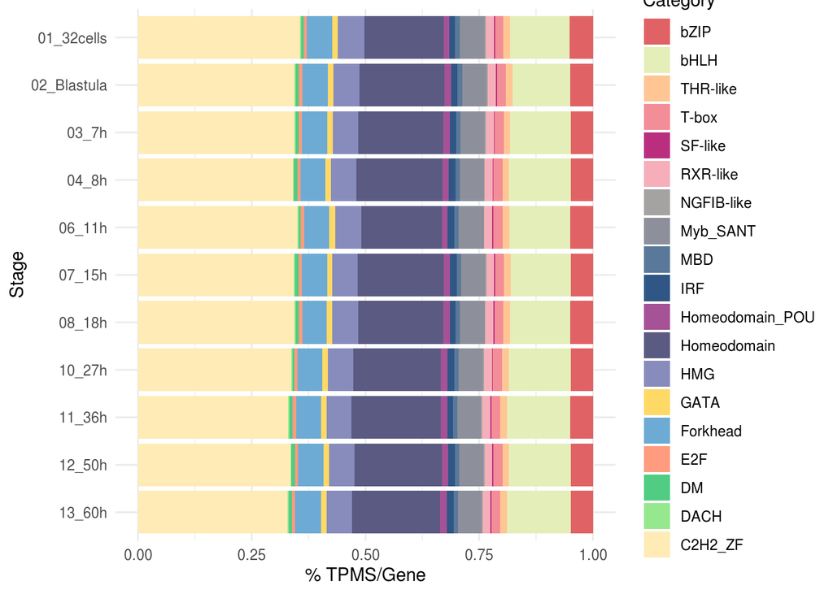

```r
blan_tfs_ngenes <-
  apply(
    blan_tfs_counts_topclass[1:12],
    2,
    function(x){ ifelse(x > 0, 1, 0) }
    )

row.names(blan_tfs_ngenes) <- blan_tfs_counts_topclass$class

blan_tfs_ngenes <-
  aggregate(
    blan_tfs_ngenes[, 1:12],
    by = list(Category = rownames(blan_tfs_ngenes)),
    FUN = sum) %>%
  arrange(Category)
# %>%
#   column_to_rownames("Category")



blan_tfs_ngenes_plot <- blan_tfs_ngenes[,12:1] %>% reshape2::melt() %>% mutate(Category = factor(Category, levels = rev(unique(Category)))) %>%
  ggplot( aes(fill=Category, y=variable, x=value)) +
  geom_bar(position="fill", stat="identity") +
  scale_fill_manual(values=rev(topclasses_col))+
  xlab("% TPMS/Gene") +
  ylab("Stage")+
  theme_minimal()
blan_tfs_ngenes_plot
```

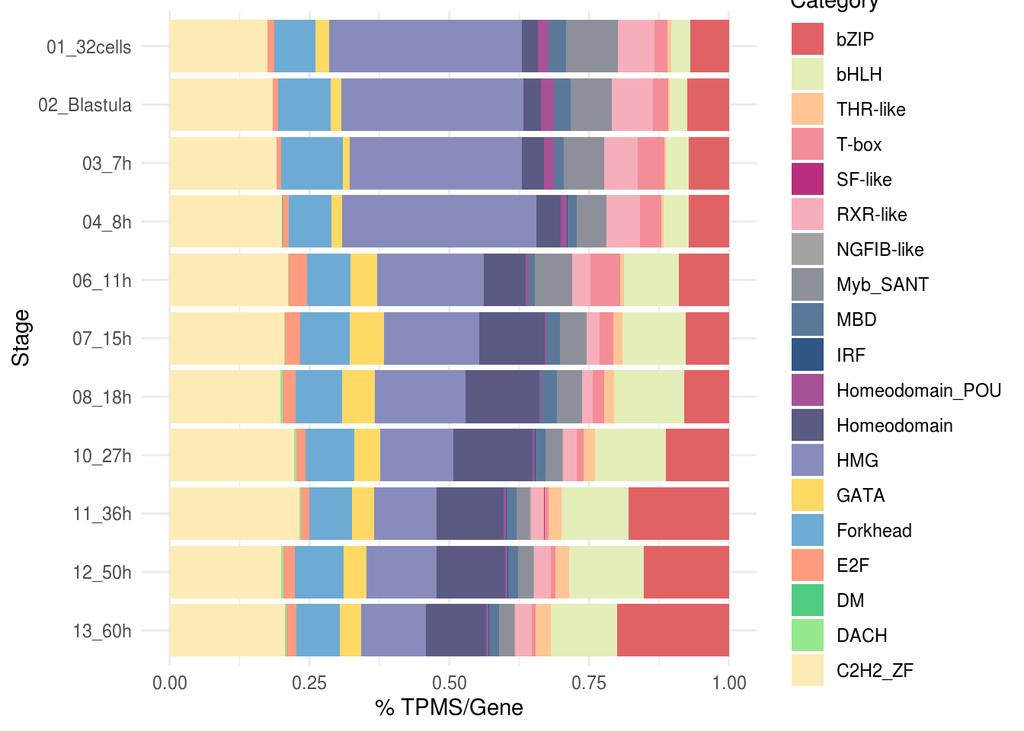

```r
blan_tfs_expgenes <-
  aggregate(
    blan_tfs_counts_topclass[, 1:12],
    by = list(Category = blan_tfs_counts_topclass$class),
    FUN = sum) %>%
  arrange(Category)


blan_tfs_expgenes_plot <- blan_tfs_expgenes[,12:1] %>% reshape2::melt() %>% mutate(Category = factor(Category, levels = rev(unique(Category)))) %>%
  ggplot( aes(fill=Category, y=variable, x=value)) +
  geom_bar(position="fill", stat="identity") +
  scale_fill_manual(values=rev(topclasses_col))+
  xlab("% TPMS/Gene") +
  ylab("Stage")+
  theme_minimal()
blan_tfs_expgenes_plot
```

We divide the cpms/class by the numexp/class, thus retrieving the cpms per class normalised by the number of expressed genes from a given class.

```r
blan_tfs_expngenes <-
  data.frame(
    Category = blan_tfs_expgenes$Category,
    blan_tfs_expgenes[,c(1:12)+1] / blan_tfs_ngenes[,c(1:12)+1]
  ) %>%
  column_to_rownames("Category")

blan_tfs_expngenes <- apply(blan_tfs_expngenes, 2, function(x){ifelse(is.nan(x),0,x)})

blan_tf_EXPNGEN <-
  apply(blan_tfs_expngenes, 2, function(x) {
    x / sum(x)
  })
```

A barplot to show the prominence/prevalence of TF classes on each cell cluster.

[figure not shown]

## TF Class Expression Variability

We can also showcase the differences in gene expression variability across TF classes by relying on the Coefficient of Variation at the class level.

```r
blan_tfs_class_cv <- merge(
  data.frame(
    id = blan_tfs$id,
    class = factor(
      blan_tfs$class,
      levels = unique(blan_tfs$class)
      )
    ),
  data.frame(
    id = rownames(blan_rna_counts_rowmeansbyrepl),
    cv = apply(
      blan_rna_counts_rowmeansbyrepl[,1:12],
      1,
      function(x){
        sd(x)/mean(x)
      }
    )
  ),
  by = 1
)[,2:3]

head(blan_tfs_class_cv)
```

```
##         class        cv
## 1 Homeodomain 0.7781540
## 2     C2H2_ZF 1.1315128
## 3 Homeodomain 1.3143436
## 4       NF-YC 0.8929385
## 5        bHLH 0.5854372
## 6     C2H2_ZF 0.6547773
```

Based on the median CV and the number of genes of each class, we can do a scatter plot and a box plot to showcase these differences:

```r
tfs_cv_scatter <-
  ggplot(blan_tfs_class_cv %>% group_by(class) %>%
           mutate( med = median(cv) ) %>%
           mutate( numgenes = log( table( as.character(class) ) ) ) ,
         aes(x = numgenes, y = med, label=class)) +
  geom_text(hjust=0, vjust=0, aes(colour = class))+
  scale_color_manual(
    values = rainbow(length(levels(blan_tfs_class_cv$class)))
    )+
  theme_classic()+
  theme(
    legend.position = "none"
  )

tfs_cv_boxplot <-
  ggplot(blan_tfs_class_cv %>% group_by(class) %>%
           mutate(med = median(cv)) %>%
           mutate(numgenes = log(table(as.character(class)))),
         aes(x = reorder(class, cv, FUN=median), y = cv)) +
  geom_boxplot(aes(fill = numgenes))+
  scale_fill_gradient(low="#00204D", high="#FFEA46")+
  theme_classic()+
  theme(
    axis.text.x = element_text(
      colour = rainbow(length(levels(blan_tfs_class_cv$class))),
      angle = 90
      )
    )
```

The Scatter plot:

```
## Defaulting to continuous.
```

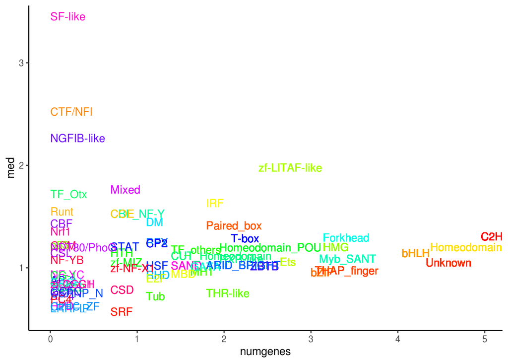

And the Box plot of each TF class

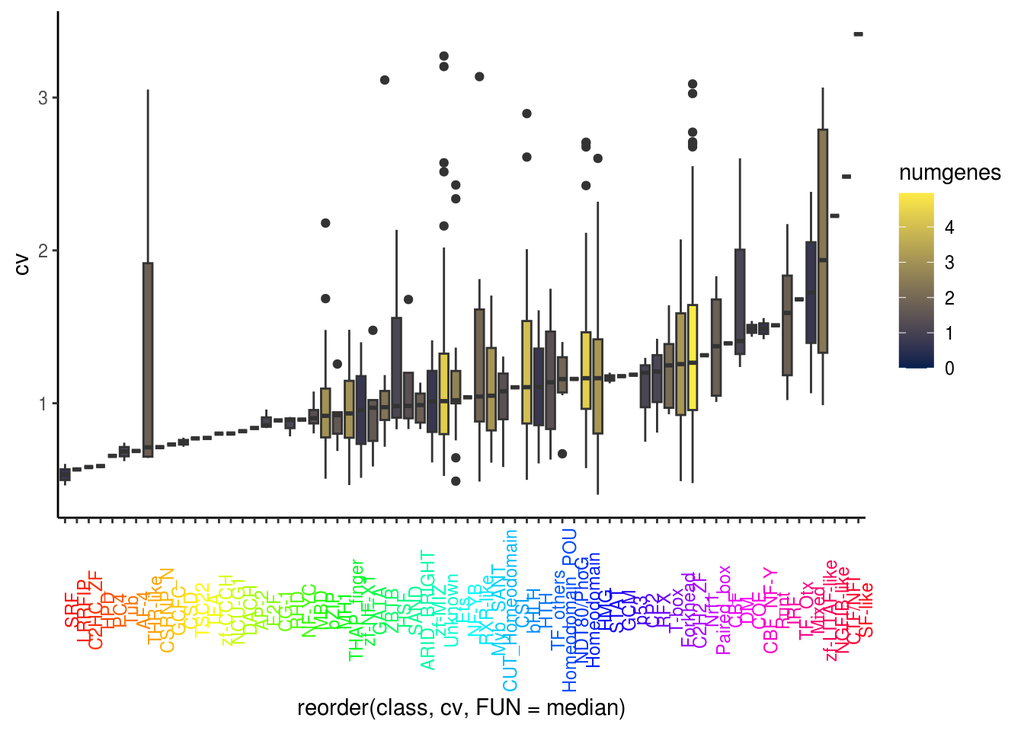

## Coexpression TF classes ~ clusters of stage-specific genes

Does the patterns of these TF classes correspond to the genes we have identified as stage-specific during development? For this we can count how many of each TF of a given class X correlates positively with the average expression profile of a given stage-specific cluster Y.

Firs we will slice again the counts of the TFs

```r
blan_tfs_counts <-
  merge(
    blan_rna_counts_rowmeansbyrepl,
    blan_tfs,
    by.x = 0,
    by.y = 1,
  ) %>%
  distinct(Row.names, .keep_all = TRUE) %>%
  column_to_rownames("Row.names")
```

And we will keep only the TFs from TFclasses with more than three annotated genes:

```r
tfclasses_morethan3genes <-
  names(table(blan_tfs$class)[table(blan_tfs$class) >3])

clusters <-
  rownames(blan_cl_avgs)
```

We create an empty matrix where to put all the data we will calculate:

```r
blan_tfs_cluster <-
  matrix(
    0,
    nrow = length(tfclasses_morethan3genes),
    ncol = length(clusters)
    )

rownames(blan_tfs_cluster) <- tfclasses_morethan3genes

colnames(blan_tfs_cluster) <- clusters

blan_tfs_cluster
```

```
##                 1 2 3 4 5 6 7 8 9 10 11 12 13 14 15 16 17 18 19 20 21 22 23 24
## ARID_BRIGHT     0 0 0 0 0 0 0 0 0  0  0  0  0  0  0  0  0  0  0  0  0  0  0  0
## bHLH            0 0 0 0 0 0 0 0 0  0  0  0  0  0  0  0  0  0  0  0  0  0  0  0
## bZIP            0 0 0 0 0 0 0 0 0  0  0  0  0  0  0  0  0  0  0  0  0  0  0  0
## C2H2_ZF         0 0 0 0 0 0 0 0 0  0  0  0  0  0  0  0  0  0  0  0  0  0  0  0
## CUT_Homeodomain 0 0 0 0 0 0 0 0 0  0  0  0  0  0  0  0  0  0  0  0  0  0  0  0
## DM              0 0 0 0 0 0 0 0 0  0  0  0  0  0  0  0  0  0  0  0  0  0  0  0
## Ets             0 0 0 0 0 0 0 0 0  0  0  0  0  0  0  0  0  0  0  0  0  0  0  0
## Forkhead        0 0 0 0 0 0 0 0 0  0  0  0  0  0  0  0  0  0  0  0  0  0  0  0
## GATA            0 0 0 0 0 0 0 0 0  0  0  0  0  0  0  0  0  0  0  0  0  0  0  0
## HMG             0 0 0 0 0 0 0 0 0  0  0  0  0  0  0  0  0  0  0  0  0  0  0  0
## Homeodomain     0 0 0 0 0 0 0 0 0  0  0  0  0  0  0  0  0  0  0  0  0  0  0  0
## Homeodomain_POU 0 0 0 0 0 0 0 0 0  0  0  0  0  0  0  0  0  0  0  0  0  0  0  0
## HSF             0 0 0 0 0 0 0 0 0  0  0  0  0  0  0  0  0  0  0  0  0  0  0  0
## IRF             0 0 0 0 0 0 0 0 0  0  0  0  0  0  0  0  0  0  0  0  0  0  0  0
## MBD             0 0 0 0 0 0 0 0 0  0  0  0  0  0  0  0  0  0  0  0  0  0  0  0
## MH1             0 0 0 0 0 0 0 0 0  0  0  0  0  0  0  0  0  0  0  0  0  0  0  0
## Myb_SANT        0 0 0 0 0 0 0 0 0  0  0  0  0  0  0  0  0  0  0  0  0  0  0  0
## Paired_box      0 0 0 0 0 0 0 0 0  0  0  0  0  0  0  0  0  0  0  0  0  0  0  0
## RXR-like        0 0 0 0 0 0 0 0 0  0  0  0  0  0  0  0  0  0  0  0  0  0  0  0
## SAND            0 0 0 0 0 0 0 0 0  0  0  0  0  0  0  0  0  0  0  0  0  0  0  0
## T-box           0 0 0 0 0 0 0 0 0  0  0  0  0  0  0  0  0  0  0  0  0  0  0  0
## TF_others       0 0 0 0 0 0 0 0 0  0  0  0  0  0  0  0  0  0  0  0  0  0  0  0
## THAP_finger     0 0 0 0 0 0 0 0 0  0  0  0  0  0  0  0  0  0  0  0  0  0  0  0
## THR-like        0 0 0 0 0 0 0 0 0  0  0  0  0  0  0  0  0  0  0  0  0  0  0  0
## Unknown         0 0 0 0 0 0 0 0 0  0  0  0  0  0  0  0  0  0  0  0  0  0  0  0
## ZBTB            0 0 0 0 0 0 0 0 0  0  0  0  0  0  0  0  0  0  0  0  0  0  0  0
## zf-LITAF-like   0 0 0 0 0 0 0 0 0  0  0  0  0  0  0  0  0  0  0  0  0  0  0  0
##                 25
## ARID_BRIGHT      0
## bHLH             0
## bZIP             0
## C2H2_ZF          0
## CUT_Homeodomain  0
## DM               0
## Ets              0
## Forkhead         0
## GATA             0
## HMG              0
## Homeodomain      0
## Homeodomain_POU  0
## HSF              0
## IRF              0
## MBD              0
## MH1              0
## Myb_SANT         0
## Paired_box       0
## RXR-like         0
## SAND             0
## T-box            0
## TF_others        0
## THAP_finger      0
## THR-like         0
## Unknown          0
## ZBTB             0
## zf-LITAF-like    0
```

We first create a large matrix of TF~stage-specific expression profile.

```r
blan_tfs_cluster_cor <-
  cor(
    scale(t(blan_tfs_vsd[1:12])),
    t(blan_cl_avgs),
    use = "pairwise.complete.obs"
    )

colnames(blan_tfs_cluster_cor) <- clusters
```

We will parse this matrix to count jhow many TFs of a given class `j` correlate positively with the expression profile of a given class `i` :

```r
for (i in clusters) {

  h <- which(clusters == i)

  for (j in tfclasses_morethan3genes) {

    n <- which(tfclasses_morethan3genes == j)

    all_tfs_class_j <- blan_tfs$id[blan_tfs$class == j]

    cors_jclass_in_imodule <-
      blan_tfs_cluster_cor[
        rownames(blan_tfs_cluster_cor) %in% all_tfs_class_j,
        colnames(blan_tfs_cluster_cor) == i
        ]

    good_tfs_jclass_in_imodule <-
      length(
        cors_jclass_in_imodule[
          cors_jclass_in_imodule > 0.6
          ]
        )

    blan_tfs_cluster[n, h] <-
      good_tfs_jclass_in_imodule / length(cors_jclass_in_imodule)
  }
}
```

A quick look at this matrix:

```r
round(blan_tfs_cluster,2)[1:5,1:5]
```

```
##                    1    2    3    4    5
## ARID_BRIGHT     0.00 0.17 0.00 0.33 0.50
## bHLH            0.02 0.00 0.02 0.00 0.05
## bZIP            0.10 0.00 0.15 0.10 0.15
## C2H2_ZF         0.13 0.09 0.29 0.17 0.25
## CUT_Homeodomain 0.50 0.00 0.25 0.25 0.00
```

And a heatmap of coexpression:

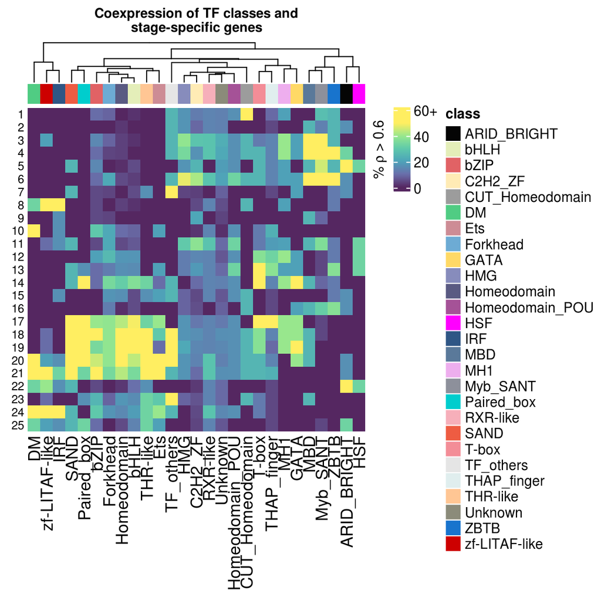

```r
Heatmap(
  name = "% cor(Sp) > 0.6",
  t(blan_tfs_cluster),
  col = tf_clusters_hm_col,
  heatmap_legend_param = list(
    title=expression(paste("% ", rho, " > 0.6")),
    title_position = "leftcenter-rot",
    at=c(0,0.2,0.4,0.6),
    labels=c("0","20","40","60+")
    ),
  row_names_side = "left",
  row_names_gp = gpar(cex=0.7),
  cluster_rows=F,
  column_title="Coexpression of TF classes and\nstage-specific genes",
  column_title_gp = gpar(cex=0.8,fontface="bold"),
  top_annotation=tfs_ha_columns(tfclasses_morethan3genes)
  )
```

## Saving the data

We will save the data for further analyses down the line.

```r
save(
  blan_tfs_vsd,
  blan_tfs_counts_topclass,
  blan_tfs_sp_hm,
  blan_tfs_exp_hm,
  blan_tfs_ngenes,
  blan_tfs_expgenes,
  blan_tf_EXPNGEN,
  blan_tfs_class_cv,
  blan_tfs_counts,
  tfclasses_morethan3genes,
  blan_tfs_cluster,
  blan_tfs_cluster_cor,
  blan_tfs_ngenes_plot,
  blan_tfs_expgenes_plot,
  blan_tf_EXPNGEN_plot,
  file = "outputs/rda/tf_analysis_blan.rda"
  )
```